# ndi_analysis

Harris Policy Lab

2/16/2021

Merging datasets

When reviewing the data, a helpful link for issues: https://github.com/ropensci/skimr/issues/606

```r
# Controls for COVID outcomes
df_covid_controls <- df_all_yr %>%
  arrange(country_standard, year) %>%
  group_by(country_standard) %>%
  # These variables don't have values in 2020. Filling in from most recent year
  fill(
    c(gdp, pub_health_exp_percent_gdp, percap_domestic_health_expenditure)) %>%
  filter(year==2020) %>%
  select(
    country_standard,
    gdp,
    pub_health_exp_percent_gdp,
    percap_domestic_health_expenditure)

df_covid_controls <- df_all_yr_2020 %>%
  select(
    country_standard, gdp_per_capita, gini_2020, median_age, aged_65_older) %>%
  full_join(df_covid_controls, by = "country_standard") %>%
  select(
    country_standard, gdp, gdp_per_capita, gini_2020,
        # we discussed using "public health expenditure as a proportion of GDP"
        # as an indicator, but it seemed very similar to the next indicator
        # below, which is "public health expenditure per capita"
    #pub_health_exp_percent_gdp,
    percap_domestic_health_expenditure,
    median_age, aged_65_older)

write_csv(df_covid_controls, "data/covid-19_controls.csv")
```

# Creating an index for COVID-19 health factors

The intuition is that countries will have a higher index score if they have fewer cases, fewer deaths, and more tests. The index is scaled from 0 (worst) to 1 (best).

We decided on this index after testing it among six considered models. We regressed each index on our list of control variables and compared the F-statistic of each model. The chosen model had the second highest F-Statistic, but was chosen because a review of the country rankings of the model with the highest F-statistic revealed it to be a poor index.

To see the code for the process above, see reference_dode/covid_index_select.r

For countries that were missing data on COVID-19 tests, they are assigned a score of “1” on the scale of 1 to 10 used for countries’ testing rates.

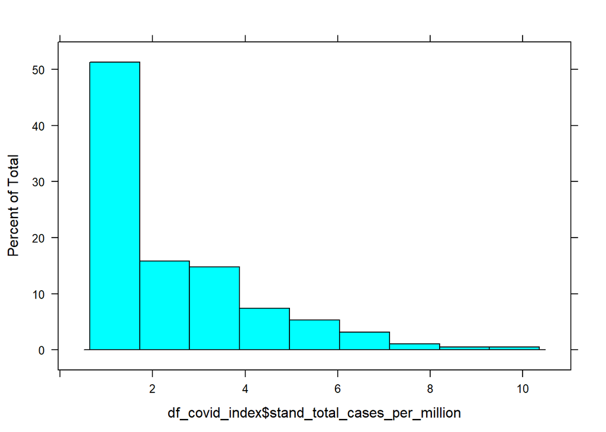

```r
df_covid_index <- df_all_yr %>%
  select(
    country_standard,
    cum_total_cases_per_million,
    cum_total_deaths_per_million,
    cum_total_tests_per_thousand) %>%
  filter(
    if_any(
      cum_total_cases_per_million:cum_total_deaths_per_million,
      ~ !is.na(.))) %>%
  distinct() %>%
  mutate(
        # Use a scale of 1 - 10 to avoid having "0" in denominator
    stand_total_cases_per_million  = rescale(cum_total_cases_per_million, to = c(1, 10)),
    stand_total_deaths_per_million = rescale(cum_total_deaths_per_million, to = c(1, 10)),
    stand_total_tests_per_thousand = rescale(cum_total_tests_per_thousand, to = c(1, 10)),
    stand_total_tests_per_thousand_no_NA = ifelse(
      is.na(stand_total_tests_per_thousand),
      1,
      stand_total_tests_per_thousand),
    covid_index = rescale(
      (1/stand_total_cases_per_million) +
      (1/stand_total_deaths_per_million) +
      stand_total_tests_per_thousand_no_NA)
    ) %>%
  select(country_standard, covid_index, everything())

# Reviewing distribution of the data
histogram(df_covid_index$stand_total_cases_per_million)
```

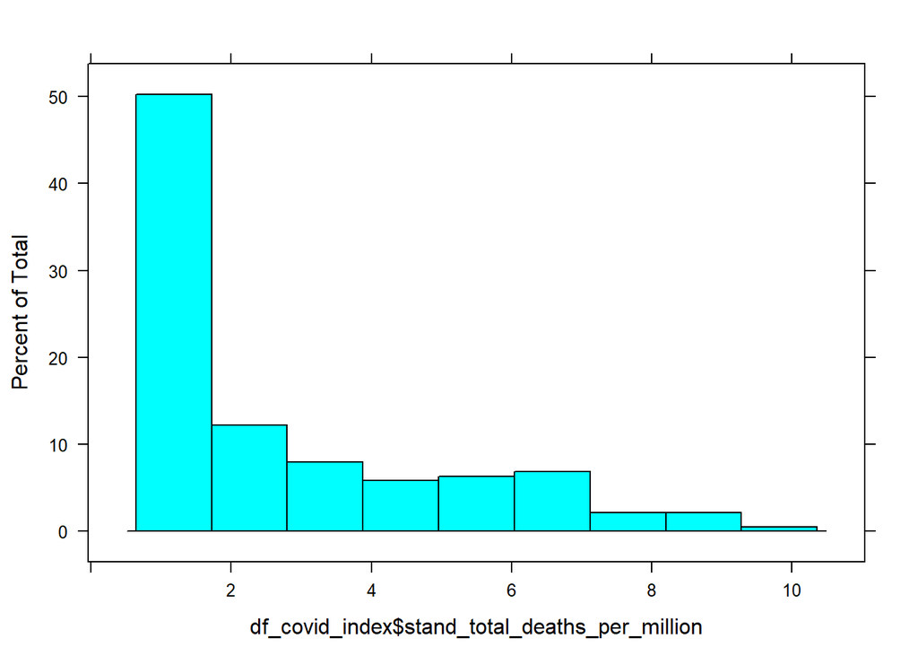

```r
histogram(df_covid_index$stand_total_deaths_per_million)
```

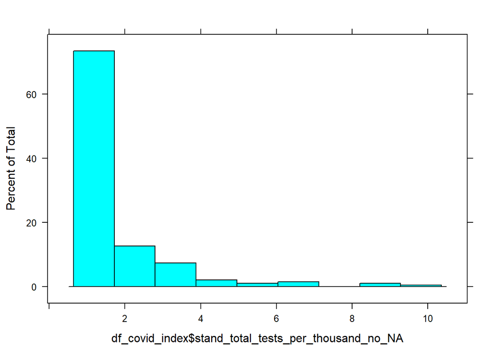

```r
histogram(df_covid_index$stand_total_tests_per_thousand_no_NA)
```

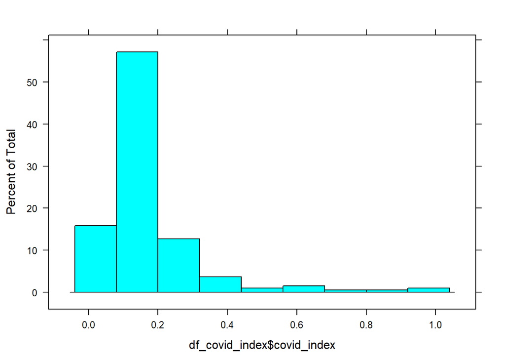

```r
histogram(df_covid_index$covid_index)
```

```r
# RUnning a regression of control variables on COVID-19 index
covid_index_mod_test <- df_covid_index %>%
  select(country_standard, covid_index) %>%
  full_join(df_covid_controls, by = "country_standard") %>%
  select(-country_standard)

  lm(covid_index ~ ., data = covid_index_mod_test) %>% summary()
```

```
##
## Call:
## lm(formula = covid_index ~ ., data = covid_index_mod_test)
##
## Residuals:
##      Min       1Q   Median       3Q      Max
## -0.34923 -0.06285  0.00081  0.03053  0.61423
##
## Coefficients:
##                                      Estimate Std. Error t value Pr(>|t|)
## (Intercept)                         3.574e-01  1.275e-01   2.803  0.00573 **
## gdp                                -5.506e-15  5.367e-15  -1.026  0.30652
## gdp_per_capita                      3.414e-06  1.068e-06   3.197  0.00169 **
## gini_2020                          -2.266e-01  1.578e-01  -1.436  0.15316
## percap_domestic_health_expenditure  2.867e-05  1.557e-05   1.842  0.06741 .
## median_age                         -1.851e-03  3.971e-03  -0.466  0.64180
## aged_65_older                      -3.558e-03  5.721e-03  -0.622  0.53491
## ---
## Signif. codes:  0 '***' 0.001 '**' 0.01 '*' 0.05 '.' 0.1 ' ' 1
##
## Residual standard error: 0.1299 on 151 degrees of freedom
##   (36 observations deleted due to missingness)
## Multiple R-squared:  0.2895, Adjusted R-squared:  0.2613
## F-statistic: 10.26 on 6 and 151 DF,  p-value: 1.64e-09
```

```r
write_csv(df_covid_index, "data/covid-19_index.csv")
```

## Notes to self:

We don’t have 2020 GDP data

There are about 20 countries missing Gini index data

From OWID Covid, look at “stringeny_index”

Additional ideas for controls:

- df_covid_owid
  - “population_density”
  - “gdp_per_capita”
  - “extreme_poverty”
  - “cardiovasc_death_rate”
  - “diabetes_prevalence”
  - “female_smokers”
  - “male_smokers”
  - “handwashing_facilities”
  - “hospital_beds_per_thousand”
  - “life_expectancy”
  - “human_development_index”

## Resources:

## Citations:

This project uses the countrycode R package

Arel-Bundock, Vincent, Nils Enevoldsen, and CJ Yetman, (2018). countrycode: An R package to convert country names and country codes. Journal of Open Source Software, 3(28), 848, https://doi.org/10.21105/joss.00848